# DENSITY ESTIMATION

In Kanai, R., Feilden, T., Firth, C. and Rees, G., 2011. Political orientations are correlated with brain structure in young adults. Current biology, 21(8), pp.677-680., data are collected to study whether or not the two brain regions are likely to be independent of each other and considering di erent types of political view For this question; you can use the proper package for histogram and KDE; no need to write your own. The data set n90pol.csv contains information on 90 university students who participated in a psychological experiment designed to look for relationships between the size of di erent regions of the brain and political views. The variables amygdala and acc indicate the volume of two particular brain regions known to be involved in emotions and decision-making, the amygdala and the anterior cingulate cortex; more exactly, these are residuals from the predicted volume, after adjusting for height, sex, and similar body-type variables. The variable orientation gives the students' locations on a ve-point scale from 1 (very conservative) to 5 (very liberal). Note that in the dataset, we only have observations for orientation from 2 to 5.

#### Forming the 1-dimensional histogram and KDE to estimate the distributions of amygdala and acc, respectively.

```
(array([ 9,  2, 11, 11, 23, 10, 14,  5,  1,  4], dtype=int64),
 array([-0.0676 , -0.05272, -0.03784, -0.02296, -0.00808,  0.0068 ,
         0.02168,  0.03656,  0.05144,  0.06632,  0.0812 ]))
```

#### Plots for distribution of amygdala

#### To get the appropriate kernel bandwidth, I am iterating over multiple possible values to observe the distribution of the data of variable amygdala. Below were the results.

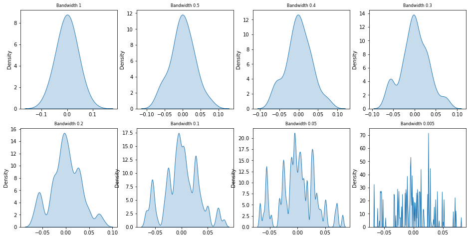

#### Bandwidths 1, 0.5, 0.4 appear to be too smooth without capturing any patterns in the data. Bandwidth 0.1 and lesser seem to have too many modes and does not give much information about the shape of the distribution. Bandwidths 0.3 and 0.2 seem to give some information about the density. I am choosing bandwith 0.3 for further analysis

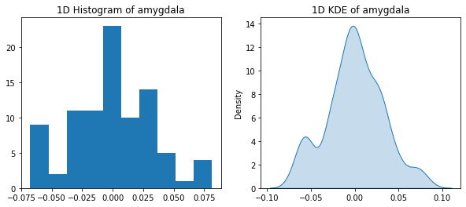

#### Plots for distribution of anterior cingulate cortex (acc)

#### To get the appropriate kernel bandwidth, I iterated over multiple possible values to observe the distribution of the data of variable amygdala. Below were the results.

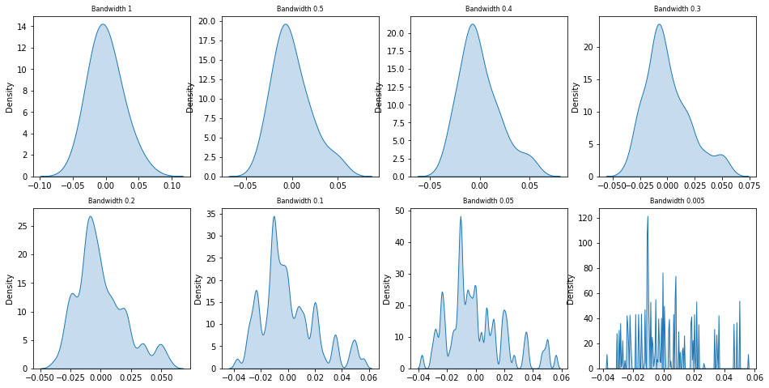

#### Bandwidths 1, 0.5, 0.4 appear to be too smooth without capturing any patterns in the data. Bandwidth 0.1 and lesser seem to have too many modes and does not give much information about the shape of the distribution. Bandwidths 0.3 and 0.2 seem to give some information about the density. I am choosing bandwith 0.3 for further analysis

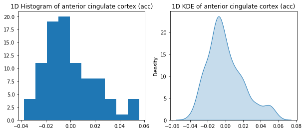

#### Forming 2-dimensional histogram for the pairs of variables (amygdala, acc). Deciding on a suitable number of bins so we can see the shape of the distribution clearly.

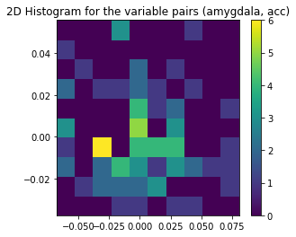

#### 3D plot

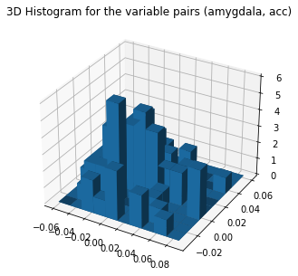

#### Looking at the distributions, we can relate this to the individual distributions of the 2 variables. While plotting the individual distribution of amygdala, we observed a peak around -0.025 to 0.025 range. For individual distribution of acc, we noticed more dense population around -0.02 to 0.0range. We can observe the same with the joint distribution as well. The bright yellow and green areas (shades 5,6) show the densely populated areas.

#### Using kernel-density-estimation (KDE) to estimate the 2-dimensional density function of (amygdala, acc) .Setting an appropriate kernel bandwidth h > 0.

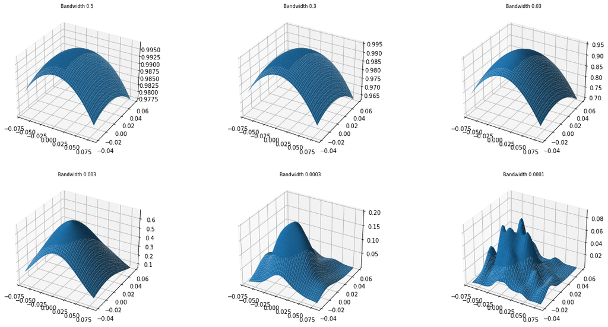

#### From the above, we can observe that bandwidth 0.0003 gives a representation of the possible data density considering both the variables. The bandwidths for this and the below contour plots differ due to different libraries used.

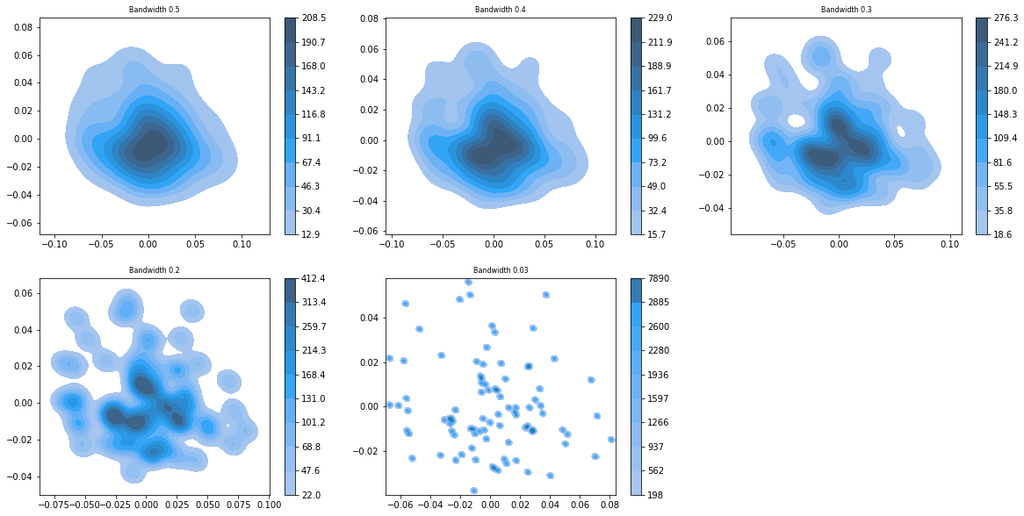

#### Based on both the 3D and 2D plots, we can observe that data density is high from -0.025 to 0.04 which matches with the 2D histogram densities.

#### Identifying Independence from conditional density and marginal density results

Looking roughly from the plots of joint distribution of amygdala and acc, and the individual distributions, we can observe that the peaks and data distribution seem similar for the joint distributions and marginal distributions.

If p(x) and p(y) represent the marginal distributions of 2 variables x and y, and p(x,y) represents their joint distribution, then we can state the two variables are independent if :  
p(x,y) = p(x)p(y)  
In other words, the difference between the density estimations for them should be close to 0. However, since we have errors associated with the density estimations of our dataset, we can identify some residuals in this difference. If the residuals are small, we could state that the variables are independent. Below were the steps followed to identify residuals and plot them  
a) Using scipy.stats.gaussian_kde, get the marginal pdf’s for amygdala and acc using 0.3 as the bandwidth.  
b) Using scipy.stats.gaussian_kde, get the joint pdf of amygdala and acc.  
c) Identify the residuals using formula absolute(p(x,y) - p(x) p(y))  
d) Plot the marginal distribution, join distribution and residuals to observe the residuals.  
Below are the results.

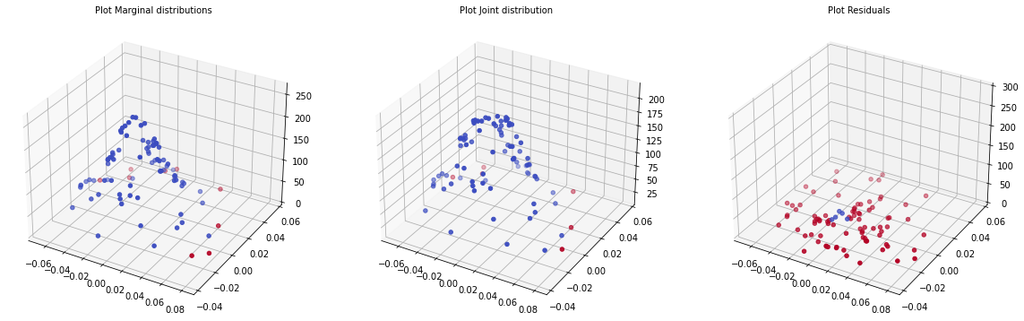

```
909.7678892987302
8.248725631208412
```

#### We cannot confirm independence since we have residuals.

### We will consider the variable orientation and consider conditional distributions. Plotting the estimated conditional distribution of amygdala conditioning on political orientation:

p(amygdalajorientation = c), c = 2; : : : ; 5, using KDE. Setting anappropriate kernel bandwidth h > 0. Implementing the same for the volume of the acc: plot p(accjorietation = c), c = 2; : : : ; 5 using KDE.

Understanding based on the results, and infering whether the conditional distribution of amygdala and acc, respectively, are different from c = 2; : : : ; 5? This is a type of scietific question one could infer from the data: Whether or not there is a difference between brain structure and political view.

##### Conditional Distribution of amygdala on orientation

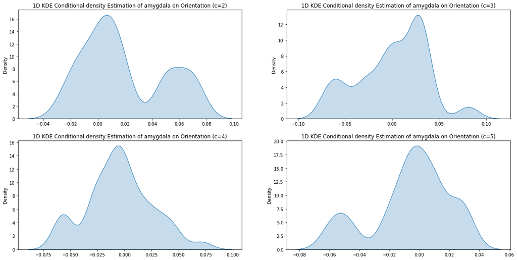

#### From the 4 plots of distributions of amygdala with the 4 types of brain orientations, we can observe that most of the data is observed around 0.00 for all 4 orientations. There is a slight difference for c=3, but it is not very significant. There is not much difference between the orientations from these plots. In other words, we cannot infer a difference between the brain structure and political view from these plots.

##### Conditional Distribution of acc on orientation

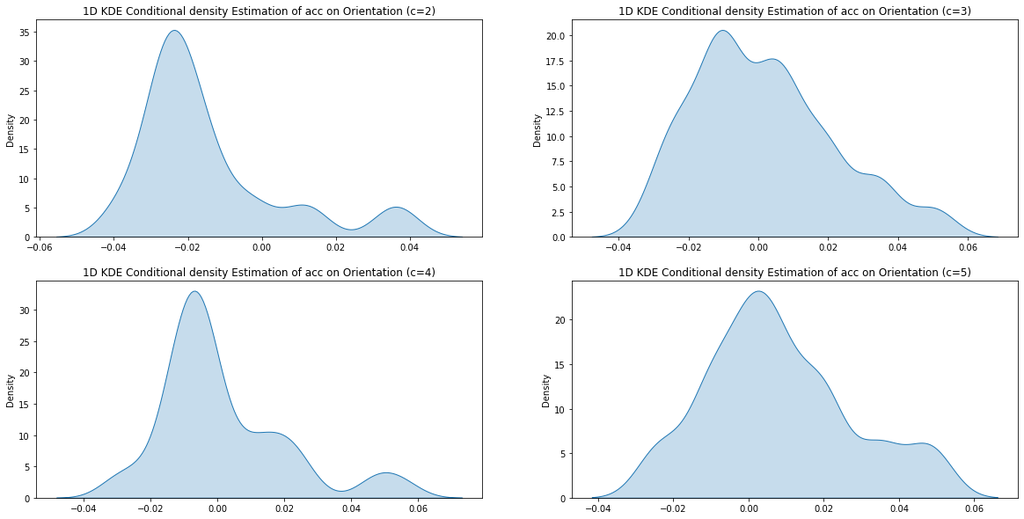

#### From the 4 plots of distributions of acc with the 4 types of brain orientations, we can observe that most of the data is observed around -0.02 to 0.00 for all 4 orientations. There is not much difference between the orientations from these plots. In other words, we cannot infer a difference between the brain structure and political view from these plots.

```
Conditional sample means for amydgala
For c=2 :  0.01906153846153846
For c=3 :  0.0005875
For c=4 :  -0.004719512195121951
For c=5 :  -0.005691666666666665
```

```
Conditional sample means for acc
For c=2 :  -0.014769230769230769
For c=3 :  0.0016708333333333338
For c=4 :  0.0013097560975609756
For c=5 :  0.008141666666666667
```

#### Considering the variable orientation. Estimating the conditional joint distribution of the volume of the amygdala and acc, conditioning on a function of political orientation: p(amygdala; accjorientation = c), c = 2; : : : ; 5. You will use two-dimensional KDE to achieve the goal; et an appropriate kernel bandwidth h > 0. Displaying the two-dimensional KDE (e.g., two-dimensional heat-map,two-dimensional contour plot, etc.).

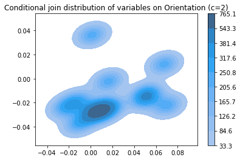

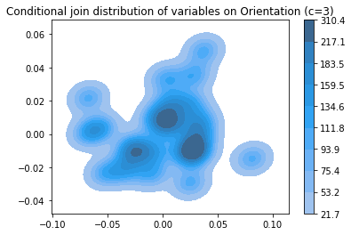

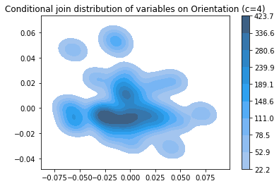

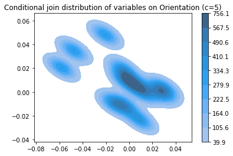

#### From the plots, we can observe that distribution for c=5 (very liberal) orientation, most of the data points are on the positive range. Few data points lie in the negative range. For the lower orientations (c=2) we observe more data points in the negative range and some in the positive range. We can observe this difference in the extreme range (c=2 and c=5). The conditional joint distributions show that very conservative (c=2) and liberal(c=5) orientations have slightly different brain structures.